# **Assignment ONE**

### Remmy Bisimbeko - B26099 - J24M19/011

#### Data Analysis and Visualization

#### My GitHub - https://github.com/RemmyBisimbeko/Data-Science

## About the iris Dataset

**Description**

The dataset contains measurements of four features (variables) for 150 iris flowers from three different species (classes).

Variable definitions

- **Sepal Length (cm)**: The length of the sepal of the flower.
- **Sepal Width (cm)**: The width of the sepal of the flower.
- **Petal Length (cm)**: The length of the petal of the flower.
- **Petal Width (cm)**: The width of the petal of the flower.
- **Species:** The species of the iris flower which is the target class

### **Starter Notebook**

###### You can accomplish this exercise in Colab, Vscode, Jupyter notebook, etc.

Installing and importing the necesary libraries

```python
# INSTALLING LIBRARIES FOR THE FIRST TIME
! pip install pandas
! pip install numpy
```

[output not shown]

```python
# After installation, then import the libraries of the installed packages
import pandas as pd
import numpy as np
```

```python
# Importing more necessary libraries
import matplotlib.pyplot as plt
import seaborn as sns
import scipy.stats as stats
from scipy.stats import shapiro, pearsonr, f_oneway, normaltest
from statsmodels.graphics.gofplots import qqplot
from statsmodels.stats.multicomp import pairwise_tukeyhsd
```

```python
! pip install google.colab
```

```python
# Run the following command to upgade version
# python3.9 -m pip install --upgrade pip
```

IMPORTING DATASETS

```python
# mounting the Google drive
# from google.colab import drive

# First Mount Google Drive
# drive.mount('/content/drive')
```

# How to read the excel file

```python
# locate the file path
# file_path = '/content/drive/My Drive/Data analytics and visualization/iris.csv'

# file_path = 'SEM 2/Data Analysis and Visualization/Assignment One/iris.csv'
file_path = 'iris.csv'
```

## Loading and Inspecting Data:

We check for any missing values in the dataset.

```python
Iris = pd.read_csv(file_path)
```

```python
Iris.head()
```

|  | Sepal.Length | Sepal.Width | Petal.Length | Petal.Width | Species |
| --- | --- | --- | --- | --- | --- |
| 0 | 5.1 | 3.5 | 1.4 | 0.2 | setosa |
| 1 | 4.9 | 3.0 | 1.4 | 0.2 | setosa |
| 2 | 4.7 | 3.2 | 1.3 | 0.2 | setosa |
| 3 | 4.6 | 3.1 | 1.5 | 0.2 | setosa |
| 4 | 5.0 | 3.6 | 1.4 | 0.2 | setosa |

```python
Iris.shape
```

```
(150, 5)
```

## **Instructions**

1. Check for any missing values in the iris dataset. Report your findings. (1 mark)
2. Explore and visually inspect the data distribution for each of the variables to understand its structure and relationships between variables. Discuss any patterns or anomalies you observe. (2 marks)
3. Create Q-Q plots for Sepal.Length, Sepal.Width, Petal.Length, and Petal.Width. Do these variables follow a normal distribution? (2 marks)
4. Check and identify any outliers in the variables. Explain your findings. (1 marks)
5. Generate Descriptive Statistics of the variables and discuss your findings. (2 marks)
6. Perform the Shapiro-Wilk test for normality on each of the quantitative variables. Interpret the results and make a conclusion. (2 marks)
7. Calculate the Pearson correlation coefficients between Sepal.Length, Sepal.Width, Petal.Length, and Petal.Width. Create a correlation matrix and interpret the relationships. (4 marks)
8. Conduct a one-way ANOVA to test if there are significant differences in Sepal.Length among the three species of iris. Interpret the results. (4 marks)
9. Perform post-hoc tests to determine which pairs of species differ significantly in Sepal.Length. (2 marks)

**Good luck**

```python
# Display the first few rows of the dataset
print("First few rows of the dataset:")
print(Iris.head())
```

```
First few rows of the dataset:
   Sepal.Length  Sepal.Width  Petal.Length  Petal.Width Species
0           5.1          3.5           1.4          0.2  setosa
1           4.9          3.0           1.4          0.2  setosa
2           4.7          3.2           1.3          0.2  setosa
3           4.6          3.1           1.5          0.2  setosa
4           5.0          3.6           1.4          0.2  setosa
```

```python
# Display the shape of the dataset
print("\nShape of the dataset:")
print(Iris.shape)
```

```
Shape of the dataset:
(150, 5)
```

## Check for missing values:

We use the isnull().sum() method to check for missing values in the dataset.

If there are no missing values, this will print all zeros.

```python
# 1. Check for any missing values in the dataset
print("\nChecking for missing values:")
missing_values = Iris.isnull().sum()
print(missing_values)
```

```
Checking for missing values:
Sepal.Length    0
Sepal.Width     0
Petal.Length    0
Petal.Width     0
Species         0
dtype: int64
```

```python
# OPTION 2
# Check for missing values
print("Checking for missing values...")
print(Iris.isnull().sum())  # If there are no missing values, this will print all zeros
```

```
Checking for missing values...
Sepal.Length    0
Sepal.Width     0
Petal.Length    0
Petal.Width     0
Species         0
dtype: int64
```

### The Dataset looks to have no missing values

## Exploratory Data Analysis:

Histograms: Provide a basic overview of the distribution of each variable.

Pairplot: Helps understand the relationships between different pairs of variables.

Explore and visually inspect the data distribution:

We create histograms for each variable using hist() to visualize the data distribution.

```
Visualizing the data distribution:
```

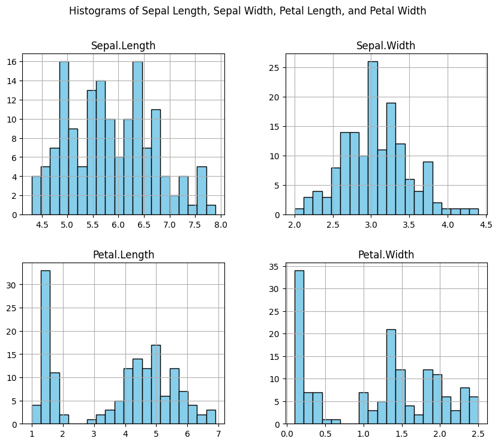

```python
# 2. Explore and visually inspect the data distribution for each variable
# Histograms for each variable
print("\nVisualizing the data distribution:")
Iris.hist(figsize=(10, 8), bins=20, color='skyblue', edgecolor='black')
plt.suptitle('Histograms of Sepal Length, Sepal Width, Petal Length, and Petal Width')
plt.show()
```

### From a glance, the data is not normally distributed

```
Exploring data distribution...
```

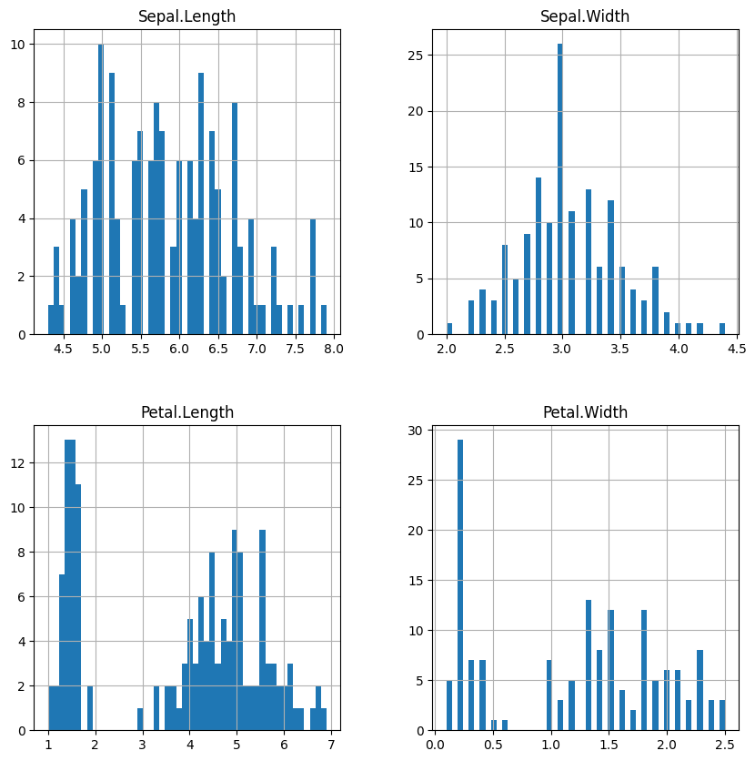

```python
# OPTION 2
# Explore and visually inspect the data distribution for each variable
print("\nExploring data distribution...")
Iris.hist(bins=50, figsize=(10, 10))  # Histograms for each variable
plt.show()
```

### From a glance, the data is not normally distributed

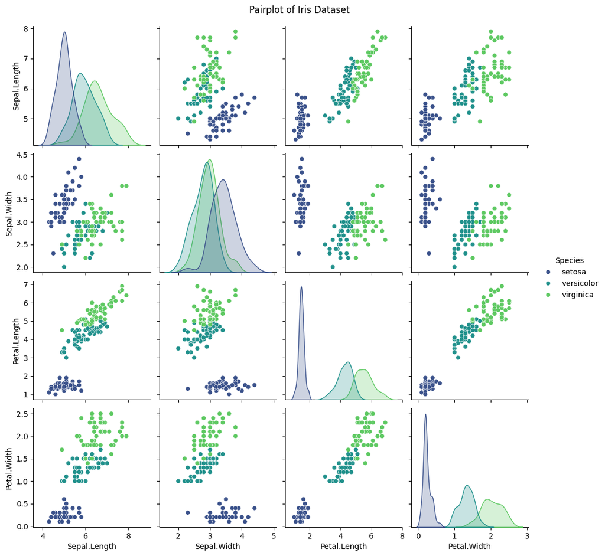

```python
# Pairplot to explore relationships between variables
sns.pairplot(Iris, hue='Species', palette='viridis')
plt.suptitle('Pairplot of Iris Dataset', y=1.02)
plt.show()
```

## Q-Q Plots:

Q-Q plots help check if the variables follow a normal distribution.

We create Q-Q plots for each variable using qqplot() to check for normality.

```
Creating Q-Q plots:
```

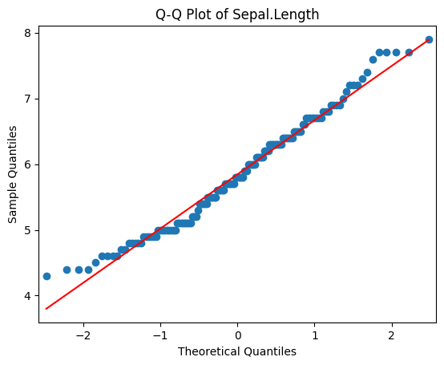

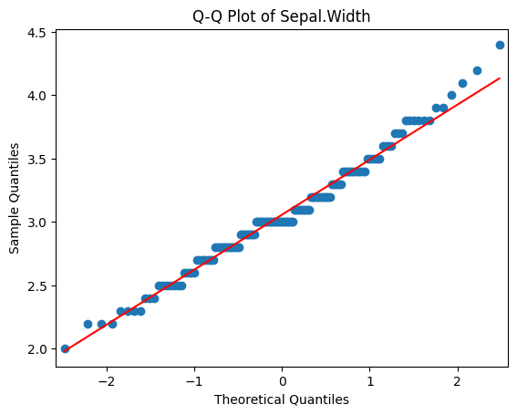

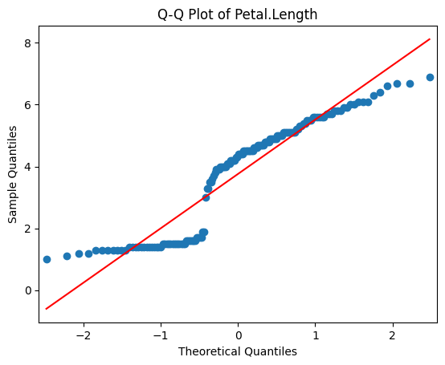

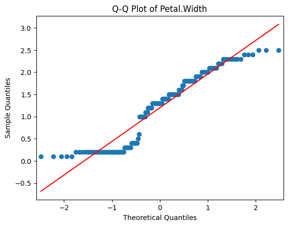

```python
# 3. Create Q-Q plots for Sepal.Length, Sepal.Width, Petal.Length, and Petal.Width
print("\nCreating Q-Q plots:")
variables = ['Sepal.Length', 'Sepal.Width', 'Petal.Length', 'Petal.Width']
for var in variables:
    qqplot(Iris[var], line='s')
    plt.title(f'Q-Q Plot of {var}')
    plt.show()
```

```
Creating Q-Q plots...
```

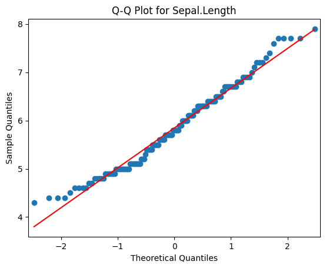

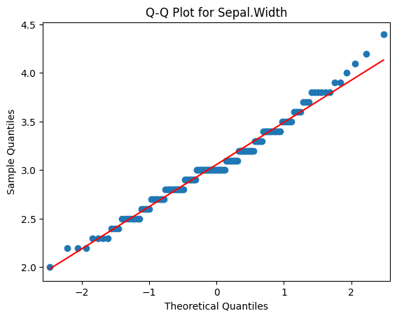

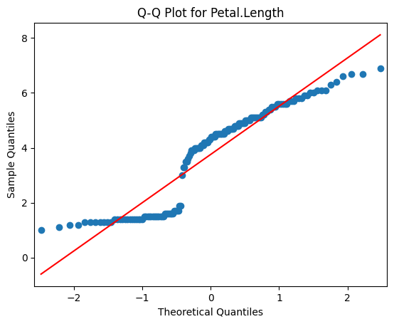

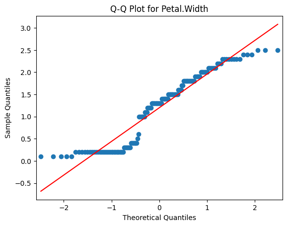

```python
# OPTION 2
# 3. Create Q-Q plots for Sepal.Length, Sepal.Width, Petal.Length, and Petal.Width
print("\nCreating Q-Q plots...")
for col in Iris.columns[:-1]:  # Exclude the Species column
    plt.figure(figsize=(6, 6))
    qqplot(Iris[col], line='s')
    plt.title(f"Q-Q Plot for {col}")
    plt.show()
```

## Outlier Detection:

Boxplots help identify outliers in the dataset.

```
Identifying outliers with boxplots:
```

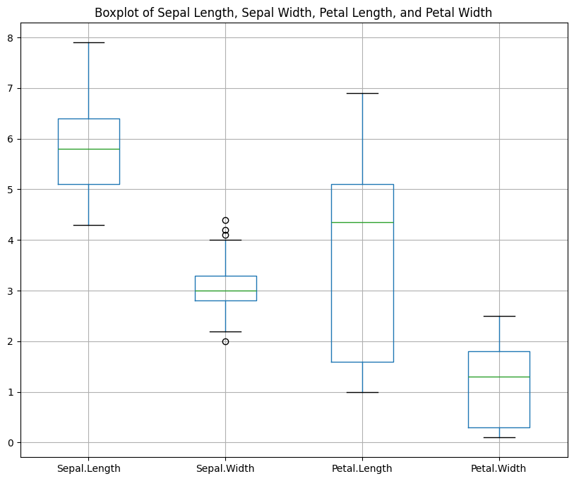

```python
# 4. Check and identify any outliers in the variables using boxplots
print("\nIdentifying outliers with boxplots:")
plt.figure(figsize=(10, 8))
Iris.boxplot(column=['Sepal.Length', 'Sepal.Width', 'Petal.Length', 'Petal.Width'])
plt.title('Boxplot of Sepal Length, Sepal Width, Petal Length, and Petal Width')
plt.show()
```

### The Sepal.length, petal.length, and petal.width don't have outliers except for sepal.width which portays outliers seen from the 3 dots outside the box and one dot below.

## Check for normality using Shapiro-Wilk test:

We use the Shapiro-Wilk test to check for normality in each variable.

If the p-value is greater than 0.05, we fail to reject the null hypothesis that the variable follows a normal distribution.

```python
# Check for normality using Shapiro-Wilk test
print("\nChecking for normality...")
for col in Iris.columns[:-1]:  # Exclude the Species column
    stat, p = shapiro(Iris[col])
    print(f"Shapiro-Wilk test for {col}: stat={stat:.2f}, p={p:.2f}")
    if p > 0.05:
        print(f"{col} follows a normal distribution (fail to reject H0)")
    else:
        print(f"{col} does not follow a normal distribution (reject H0)")
```

```
Checking for normality...
Shapiro-Wilk test for Sepal.Length: stat=0.98, p=0.01
Sepal.Length does not follow a normal distribution (reject H0)
Shapiro-Wilk test for Sepal.Width: stat=0.98, p=0.10
Sepal.Width follows a normal distribution (fail to reject H0)
Shapiro-Wilk test for Petal.Length: stat=0.88, p=0.00
Petal.Length does not follow a normal distribution (reject H0)
Shapiro-Wilk test for Petal.Width: stat=0.90, p=0.00
Petal.Width does not follow a normal distribution (reject H0)
```

## Calculate descriptive statistics:

Summary statistics for each variable provide insights into the data.

We use the describe() method to calculate descriptive statistics for each variable.

```python
# 5. Generate Descriptive Statistics of the variables
print("\nDescriptive Statistics:")
desc_stats = Iris.describe()
print(desc_stats)
```

```
Descriptive Statistics:
       Sepal.Length  Sepal.Width  Petal.Length  Petal.Width
count    150.000000   150.000000    150.000000   150.000000
mean       5.843333     3.057333      3.758000     1.199333
std        0.828066     0.435866      1.765298     0.762238
min        4.300000     2.000000      1.000000     0.100000
25%        5.100000     2.800000      1.600000     0.300000
50%        5.800000     3.000000      4.350000     1.300000
75%        6.400000     3.300000      5.100000     1.800000
max        7.900000     4.400000      6.900000     2.500000
```

```python
# Calculate descriptive statistics option 2
print("\nDescriptive statistics...")
print(Iris.describe())
```

```
Descriptive statistics...
       Sepal.Length  Sepal.Width  Petal.Length  Petal.Width
count    150.000000   150.000000    150.000000   150.000000
mean       5.843333     3.057333      3.758000     1.199333
std        0.828066     0.435866      1.765298     0.762238
min        4.300000     2.000000      1.000000     0.100000
25%        5.100000     2.800000      1.600000     0.300000
50%        5.800000     3.000000      4.350000     1.300000
75%        6.400000     3.300000      5.100000     1.800000
max        7.900000     4.400000      6.900000     2.500000
```

## Check for outliers:

We use the Z-score method to detect outliers in each variable. If a row has a Z-score greater than 3, it is considered an outlier.

```python
# 10. Check for outliers using the Z-score method
print("\nChecking for outliers...")
z_scores = np.abs(stats.zscore(numeric_columns))
outliers = numeric_columns[(z_scores > 3).any(axis=1)]
print("Outliers:")
print(outliers)
```

```
Checking for outliers...
Outliers:
    Sepal.Length  Sepal.Width  Petal.Length  Petal.Width
15           5.7          4.4           1.5          0.4
```

## Normality Test:

The Shapiro-Wilk test checks if the variables follow a normal distribution.

```python
# 6. Perform the Shapiro-Wilk test for normality on each of the quantitative variables
print("\nShapiro-Wilk Test for Normality:")
for var in variables:
    stat, p = shapiro(Iris[var])
    print(f'\n{var}: Statistics={stat}, p-value={p}')
    if p > 0.05:
        print(f'{var} looks Gaussian (fail to reject H0)')
    else:
        print(f'{var} does not look Gaussian (reject H0)')
```

```
Shapiro-Wilk Test for Normality:

Sepal.Length: Statistics=0.9760902723490532, p-value=0.010181161454691156
Sepal.Length does not look Gaussian (reject H0)

Sepal.Width: Statistics=0.9849178695056319, p-value=0.10115426916130282
Sepal.Width looks Gaussian (fail to reject H0)

Petal.Length: Statistics=0.8762680554631075, p-value=7.412263135173186e-10
Petal.Length does not look Gaussian (reject H0)

Petal.Width: Statistics=0.9018349381915991, p-value=1.680465210314913e-08
Petal.Width does not look Gaussian (reject H0)
```

## Calculate Pearson correlation coefficients:

Pearson correlation coefficients and a heatmap show relationships between variables.

We calculate the Pearson correlation coefficients between each pair of variables using corr().

```python
# 7. Calculate the Pearson correlation coefficients between the variables and create a correlation matrix
print("\nCalculating Pearson Correlation Coefficients:")
# Exclude the 'Species' column
# Converting needed from strings to float, or removing them
numeric_columns = Iris.drop(columns='Species')
corr_matrix = numeric_columns.corr()
print(corr_matrix)
```

```
Calculating Pearson Correlation Coefficients:
              Sepal.Length  Sepal.Width  Petal.Length  Petal.Width
Sepal.Length      1.000000    -0.117570      0.871754     0.817941
Sepal.Width      -0.117570     1.000000     -0.428440    -0.366126
Petal.Length      0.871754    -0.428440      1.000000     0.962865
Petal.Width       0.817941    -0.366126      0.962865     1.000000
```

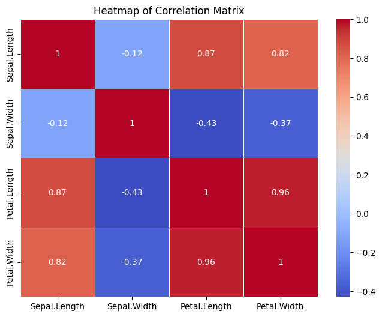

```python
# Heatmap of the correlation matrix
plt.figure(figsize=(8, 6))
sns.heatmap(corr_matrix, annot=True, cmap='coolwarm', linewidths=0.5)
plt.title('Heatmap of Correlation Matrix')
plt.show()
```

Sepal.Length and Sepal.Width: There is a very weak negative correlation (-0.118).

Sepal.Length and Petal.Length: There is a strong positive correlation (0.872).

Sepal.Length and Petal.Width: There is a strong positive correlation (0.818).

Sepal.Width and Petal.Length: There is a moderate negative correlation (-0.428).

Sepal.Width and Petal.Width: There is a moderate negative correlation (-0.366).

Petal.Length and Petal.Width: There is a very strong positive correlation (0.963).

This gives us an idea and relationship between the variables with the Iris Dataset

For example, the robust positive correlation seen between Petal.Length and Petal.Width indicates that as the length of the petal increases, its width also typically increases.

## One-way ANOVA Test:

A one-way ANOVA test checks if there are significant differences in Sepal Length among the three species.

We perform a one-way ANOVA to test for differences in Sepal.Length among species. If the p-value is less than 0.05, we reject the null hypothesis that there are no significant differences.

```python
# 8. Conduct a one-way ANOVA to test if there are significant differences in Sepal.Length among the three species
print("\nConducting One-way ANOVA for Sepal.Length:")
f_stat, p_val = f_oneway(Iris[Iris['Species'] == 'setosa']['Sepal.Length'],
                         Iris[Iris['Species'] == 'versicolor']['Sepal.Length'],
                         Iris[Iris['Species'] == 'virginica']['Sepal.Length'])
print(f'F-statistic={f_stat}, p-value={p_val}')
if p_val < 0.05:
    print("There are significant differences in Sepal.Length among the species (reject H0)")
else:
    print("No significant differences in Sepal.Length among the species (fail to reject H0)")
```

```
Conducting One-way ANOVA for Sepal.Length:
F-statistic=119.26450218450468, p-value=1.6696691907693826e-31
There are significant differences in Sepal.Length among the species (reject H0)
```

```python
# OPTION 2
# One-way ANOVA to test for differences in Sepal.Length among species
print("\nOne-way ANOVA...")
species = Iris['Species'].unique()
sepal_lengths = [Iris[Iris['Species'] == species]['Sepal.Length'] for species in species]
f_stat, p_val = f_oneway(*sepal_lengths)
print(f"F-statistic: {f_stat:.2f}, p-value: {p_val:.2f}")
if p_val < 0.05:
    print("Reject H0: There are significant differences in Sepal.Length among species")
else:
    print("Fail to reject H0: There are no significant differences in Sepal.Length among species")
```

```
One-way ANOVA...
F-statistic: 119.26, p-value: 0.00
Reject H0: There are significant differences in Sepal.Length among species
```

As seen, the p-value (1.67e-31) is significantly less than 0.05, leading to the rejection of the null hypothesis.

So, we conclude that there exists a significant difference in Sepal.Length among the three species of iris.

## Post-hoc tests and Analysis:

Tukey's HSD test determines which pairs of species differ significantly in Sepal Length.

We use Tukey's HSD to perform post-hoc tests to determine which pairs of species differ significantly in Sepal.Length.

```python
# 9. Perform post-hoc tests to determine which pairs of species differ significantly in Sepal.Length
print("\nPerforming Post-hoc Tukey HSD Test:")
tukey_result = pairwise_tukeyhsd(Iris['Sepal.Length'], Iris['Species'])
print(tukey_result)
```

```
Performing Post-hoc Tukey HSD Test:
   Multiple Comparison of Means - Tukey HSD, FWER=0.05
=========================================================
  group1     group2   meandiff p-adj lower  upper  reject
---------------------------------------------------------
    setosa versicolor     0.93   0.0 0.6862 1.1738   True
    setosa  virginica    1.582   0.0 1.3382 1.8258   True
versicolor  virginica    0.652   0.0 0.4082 0.8958   True
---------------------------------------------------------
```

```python
# Post-hoc tests using Tukey's HSD
print("\nPost-hoc tests...")
tukey = pairwise_tukeyhsd(endog=Iris['Sepal.Length'], groups=Iris['Species'], alpha=0.05)
print(tukey)
```

```
Post-hoc tests...
   Multiple Comparison of Means - Tukey HSD, FWER=0.05
=========================================================
  group1     group2   meandiff p-adj lower  upper  reject
---------------------------------------------------------
    setosa versicolor     0.93   0.0 0.6862 1.1738   True
    setosa  virginica    1.582   0.0 1.3382 1.8258   True
versicolor  virginica    0.652   0.0 0.4082 0.8958   True
---------------------------------------------------------
```

After reviewing the results ffrom the Tukey HSD test, we see that there are differences in Sepal.Length between all pairs of species.

Secondly, the p-values for all comparisons are verry small (0.0), which pushes us to the rejection of null hypothesis for each pair. This indicates that the mean Sepal.Length differs significantly across all pairs of species.